# Study - Statistics Without the Agonizing Pain.

John Rauser ( 2014). Statistics Without the Agonizing Pain. Strata Hadoop 2014. Retrieved from https://www.youtube.com/watch?v=5Dnw46eC-0o

(Source: https://www.youtube.com/watch?v=5Dnw46eC-0o )

```python
import numpy as np
import pandas as pd
%matplotlib inline
import matplotlib.pyplot as plt
import scipy.stats as stats
```

```python
data = pd.read_csv('mosquitos_data.csv')
```

```python
beer,water = (data.groupby('Treatment')['Response'].apply(list))
```

```python
beer = np.array(beer)
water = np.array(water)
```

```python
print(f"For the beer test sample Mean is: {beer.mean().round(2)}, Standard Deviation is: {beer.std().round(5)}, and Median is: {np.median(beer)}")
```

```
For the beer test sample Mean is: 23.6, Standard Deviation is: 4.04969, and Median is: 24.0
```

```python
print(f"For the water test sample Mean is: {water.mean().round(2)}, Standard Deviation is: {water.std().round(5)}, and Median is: {np.median(water)}")
```

[output not shown]

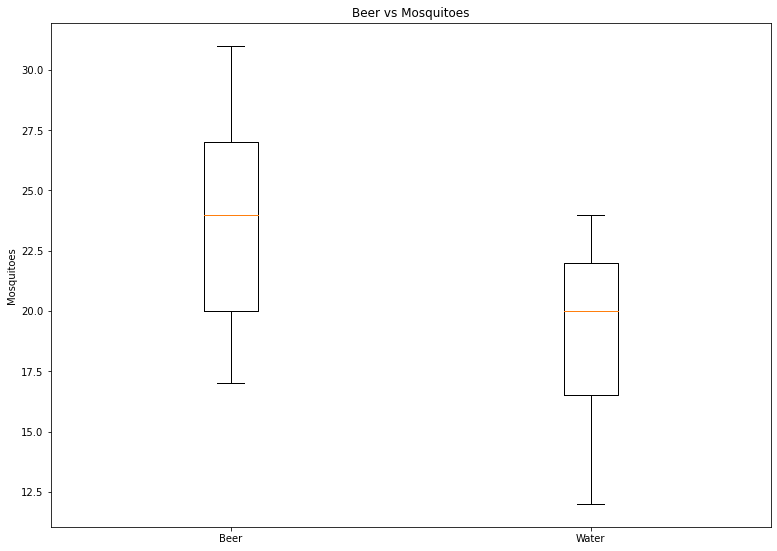

```python
data = [beer, water]

fig = plt.figure(figsize =(10, 7))

ax = fig.add_axes([0, 0, 1, 1])

bp = ax.boxplot(data)

plt.title("Beer vs Mosquitoes")

ax.set_xticklabels(["Beer","Water"])

ax.set_ylabel("Mosquitoes")
plt.show()
```

For the beer test sample Mean is: 23.6, Standard Deviation is: 4.04969, and Median is: 24.0 For the water test sample Mean is: 19.22, Standard Deviation is: 3.56769, and Median is: 20.0 As we can see from the mean and standard deviation of our tests the average amount of mosquitoes is lower in the Water sample group by 4.4 points. Additionaly as we can see from our boxplots is that Water test group has a downward spread compared to the Beer sample where the spread of results is upward facing. That much of a difference between tests does warrant an assumption that Beer in fact attracts more mosquitoes than water. However because the sample is so small it can be challenged by a sceptic. To prove correlation we must undergo the process of permutation test to display that a variance between tests without correlation as high as 4.4 is so unlikely to happen that it proves correlation.

```python
concat = np.concatenate((beer,water), axis = None)
```

```python
mean_simulation = 0
mean_distribution = []
for i in range(10000):
    perm = np.random.permutation(concat)
    beer_concat = perm[:25]
    water_concat = perm[25:]
    mean_distribution.append(beer_concat.mean() - water_concat.mean())
    if beer_concat.mean() - 4.4 >= water_concat.mean():
        mean_simulation +=1
mean_simulation
```

```
5
```

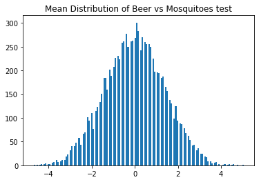

```python
plt.hist(mean_distribution, bins = 150)
plt.title("Mean Distribution of Beer vs Mosquitoes test")
```

When put to the permutation test we find that out of 10,000 tries we only get 5 instances where the mean of the Beer sample is equal or larger by 4.4 points than the Water sample. Those odds are 5/10,000 = 0.05%, an incredable confidence coefficient. As you can see from the histogram above the mean distribution of our test is distributed evenly around 0, showcasing how unlikely it is for our test to return unsubstatiated results. What it means for our research is that the odds of the research results being lucky are incredibly low, this solidifies the conclusion that Beer in fact does attract more mosquitoes than Water when consumed by people.